# Gender and Development

Carolina Torreblanca

University of Pennsylvania

**Global Development**: Intermediate Topics in Politics, Policy, and Data

PSCI 3200 - Spring 2026

## Agenda

- Development and Gender
- Chattopadhyay and Duflo, 2004
- Interaction Models

## Upcoming Deadlines

- **Expanded Research Design** – April 15, 2026
  - Refined research plan: RQ, hypothesis, design, limitations
  - Submit via Slack by 11:59pm EST
- **Final Project** – April 29, 2026
  - Full analysis + professional webpage
  - Submit via Slack by 11:59pm EST

## Gender and Representation

[figure not shown]

## Gender and Representation

- Women hold only 27.0% of legislative seats (IPU, 2023)
- 23% of cabinet positions (UNWOMEN)
- Disputed gender gap in turnout, large variance

## Gender and Development

[figure not shown]

## Gender and Development

- Female labor force participation rate: ~47% vs. ~73% male (ILO, 2023)
- Gender wage gap [(Pew)](https://www.pewresearch.org/social-trends/2023/03/01/the-enduring-grip-of-the-gender-pay-gap/)
- 1/3 of women have experienced GBV
- Literacy gap: 90% male vs. 83% female (World Bank, 2022)

## Gender, Development, and Representation

- The two are undoubtedly related
- But could improving gender representation produce development?

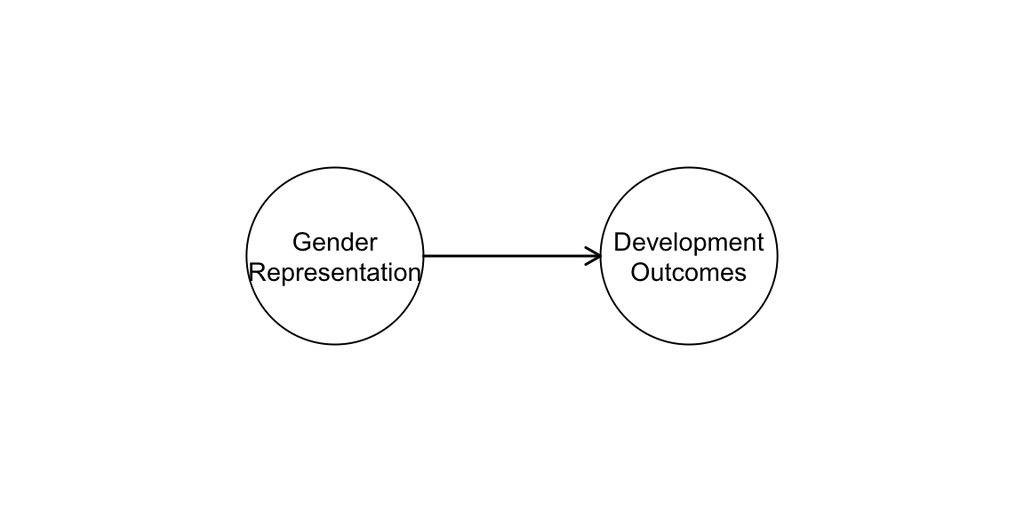

## From Representation to development

**Why might having more women in office improve development?**

- Women may want different things
- Women may behave differently
- Women may be better at their job
- Women representatives may teach about equality

## Our Expectations

- **Different outcomes?**
  - Do women prioritize different policy domains?
- **Better outcomes?**
  - Potential improvements in service delivery and reduced corruption
- **Conditionally different outcomes?**
  - Effectiveness depends on institutional context
  - Critical mass may be necessary
  - Interactions with other social identities

## Empirical Test?

- Seems like a good theory with important implications that we want to validate empirically
- Imagine we have data on share of female legislators and many development outcomes
- We compare places with female politicians to places with male politicians and see development differences
- What is the problem with this?

## A (more realistic) DAG

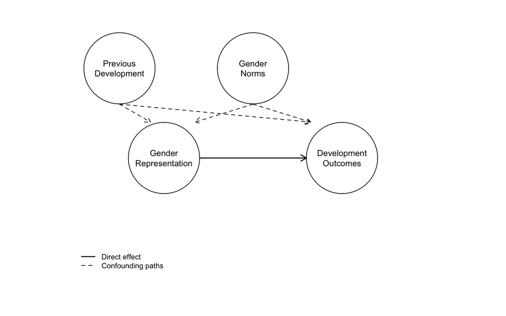

## Gender Quotas: What are they?

- Rules requiring minimum women’s representation in politics
- Goal: Improve gender parity in government
- Vary by country, region, and level of government
- Typically set minimum thresholds (20-50%)

## Gender Quotas: Types

- **Voluntary quotas**:
  - Set by political parties themselves
  - No legal enforcement
- **Mandatory quotas**:
  - Required by law
    - **Reserved seats**:
      - Specific seats only women can hold
    - **Candidate quotas**:
      - Parties must nominate certain % of women

## Gender Quota Adoption

- Started in 1990s, expanded rapidly
- Now used in about 130 countries
- Most common in newer democracies
- Less common in older democracies (US, Japan)
- Highest representation achieved in Rwanda (61%)

## Chattopadhyay and Duflo, 2004

- India reserved 1/3 of village council (panchayat) head positions for women (1993)
- Reserved positions assigned by random lottery
- Randomization creates natural experiment
- Solves confounding problem $\rightarrow$ can identify causal effects!

## The Research Question

Does mandated representation of women change policy outcomes?

- Reserved positions assigned by random lottery
- Do villages with female heads invest differently than those with male heads?

## Theory

**Hypothesis:** Reserved villages invest more in goods women prioritize

- **Mechanism:** Heterogeneous priorities
  - Women and men have different policy preferences
  - Female leaders translate those preferences into policy
- If true: representation has substantive, not just symbolic, value

## Research Design

**Treatment:** Village council randomly assigned a female head (reserved seat lottery)

- **Identification:** Randomization via lottery
  - Reserved vs. non-reserved villages are comparable on all other dimensions
- **Outcome:** Public investment decisions (type and quantity)
- **Data:** Village councils in West Bengal and Rajasthan, India

## Measuring $D_i$: Gender Differences in Requests

- Authors surveyed villagers: *“Have you made a request to the GP in the past 6 months?”*
- Requests = complaints or petitions for specific public goods (water, roads, irrigation…)
- For each good $i$, $D_i$ = share of women requesting it minus share of men requesting it
- Positive $D_i$: women want it more. Negative: men want it more.

## A bit more detail

$Y_{ij} = \beta_1 + \beta_2 * R_j + \beta_3 D_i * R_j + \sum_{l=1}^{N} \beta_l d_{li} + \epsilon_{ij}$

Where:

- $Y_{ij}$ is an outcome of interest
- $R_j$ takes the value of 1 if GP is reserved
- $D_i$ is gender difference in requests for that good (women - men)
- $d_{li}$ are good Fixed Effects!

## Main Findings

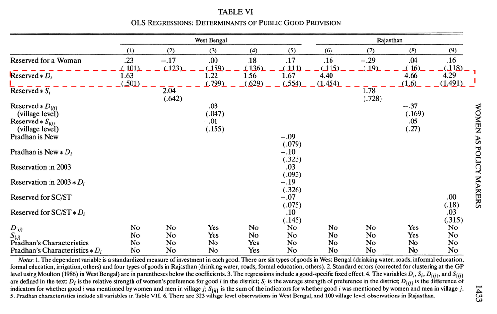

# Interaction Terms

## What are Interaction Terms?

- An interaction term is the product of two variables used as a covariate in a regression model
- Captures how the effect of one variable depends on the value of another variable
- Powerful for testing conditional hypotheses  
  **Key Modeling Assumption**

An increase in $X$ is associated with an increase in $Y$ only when a specific condition is met

## Recap: OLS Interpretation Basics

$Y_{i} = \alpha + \beta_1 * X_i + \beta_2 * Z_i + \epsilon_{i}$

- $\hat{\beta_1}$ represents the change in $Y$ when $X$ increases by one unit
- $\hat{\beta_2}$ represents the change in $Y$ when $Z$ increases by one unit
- Why?

## Coefficients as Marginal Changes

A partial derivative of the equation shows how $Y$ changes when $X$ changes by 1:

$Y_{i} = \alpha + \beta_1 * X_i + \beta_2 * Z_i + \epsilon_{i}$

- $\frac{\partial Y}{\partial X} = \beta_1$
- $\frac{\partial Y}{\partial Z} = \beta_2$

## Interaction Effects

- Idea, the effect of X on Y depends on Z

$Y = \alpha + \beta_1X + \beta_2Z + \beta_3(X*Z) + \epsilon$

## Think of it as another covariate!

| X | Z | X.Z |
| --- | --- | --- |
| 0 | 0 | 0 |
| 1 | 0 | 0 |
| 0 | 1 | 0 |
| 1 | 1 | 1 |

- What needs to happen for the new covariate to be 1?

## New model

$Y_{i} = \alpha + \beta_1 * X_i + \beta_2 * Z_i + \beta_3 * Z_i * X_i + \epsilon_{i}$

## Back to Math!

**Why does the interpretation of $\beta_1$ and $\beta_2$ change?**

$Y_{i} = \alpha + \beta_1 * X_i + \beta_2 * Z_i + \beta_3 * Z_i * X_i \epsilon_{i}$

- $\frac{\partial Y}{\partial X} = \beta_1 + \beta_3*Z_i$
- $\frac{\partial Y}{\partial Z} = \beta_2 + \beta_3*X_i$

## Three Simple Rules for Interaction

1. Use for conditional hypotheses
2. Always include all constituent terms
3. Interpret $\beta_1$ and $\beta_2$ correctly

## Marginal Effects: The Idea

Recall:

$$\frac{\partial Y}{\partial X} = \beta_1 + \beta_3 \cdot Z$$

- The effect of $X$ on $Y$ is **not a single number** – it depends on $Z$
- `marginaleffects` evaluates this at specified values of $Z$ and computes uncertainty

Two cases: $Z$ is **binary** vs. $Z$ is **continuous**

## Binary Moderator: Two Estimates

```r
# Effect of women's representation on policy outcome, by quota status
slopes(model_binary,
       variables = "women_rep",
       by = "quota")
```

```
      Term quota Estimate Std. Error    z Pr(>|z|)     S  2.5 % 97.5 %
 women_rep     0   -0.547      0.177 -3.1  0.00194   9.0 -0.893 -0.201
 women_rep     1    2.351      0.185 12.7  < 0.001 120.6  1.989  2.714

Type:  response
Columns: term, quota, estimate, std.error, statistic, p.value, s.value, conf.low, conf.high
```

## Binary Moderator: Plot

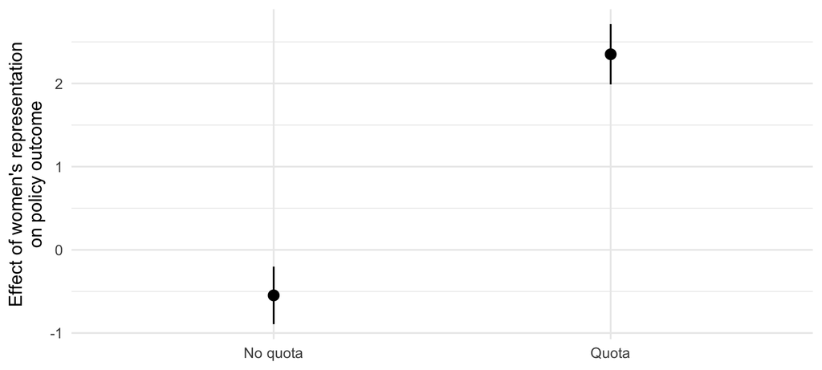

## Continuous Moderator: A Line, Not Two Points

When $Z$ is continuous, the marginal effect varies **across the full range of $Z$**

Back to C&D logic: as $D_i$ increases (women want a good more relative to men), does the effect of reservation on investment grow?

## Continuous Moderator: Plot

```r
plot_slopes(model_cont,
            variables = "reservation",
            condition = "pref_gap") +
  geom_hline(yintercept = 0, linetype = "dashed", color = "grey40") +
  labs(x = expression(D[i] ~ "(gender gap in requests: women - men)"),
       y = "Effect of GP reservation\non public investment",
       caption = "Simulated data") +
  theme_minimal(base_size = 16)
```

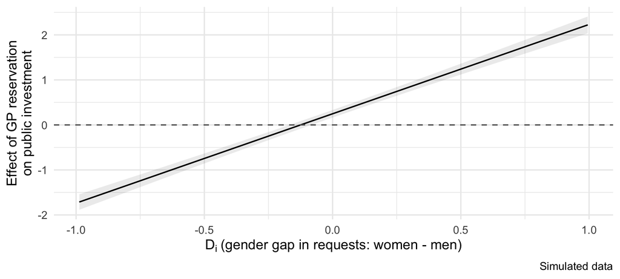

## What to Look For

**Binary moderator** - Two point estimates with CIs – does the effect change sign or magnitude?

**Continuous moderator** - A line with CI band – where does the effect become significant? Where does it flip?

Both are $\beta_1 + \beta_3 \cdot Z$ evaluated at different values of $Z$ – `marginaleffects` handles the standard errors